# QTM 151 - Quiz 5

## Try to submit as an HTML file

Print your name below

```python
# Write your answer here

print("Sigrid Matthews")
```

```
Sigrid Matthews
```

This quiz is open book

- You can use the lecture notes
- You will get partial credit for attempting the questions
- To get full credit, the code should run as intended
- You should NOT communicate with other students

Print the following message:

"I will abide by Emory's code of conduct"

```python
# Write your answer here:


print("I will abide by Emory's code of conduct")
```

```
I will abide by Emory's code of conduct
```

Import the libraries "matplotlib.pyplot" and "pandas"

```python
# Write your answer here

import matplotlib.pyplot as plt
import pandas as pd
```

In this quiz you will work with exchange rate data on bitcoin,  
for two exchange platforms:

- 1 coin base bit coin (CB) to dollar (USD)
- 1 ethereum bit coin (ET) to dollar (USD).

(a) Import and parse dates

- Import the dataset "bitcoin.csv"
- Parse the "date_string" column with `pd.to_datetime()`
- To get full points, set the "format" option using wildcards as in Lecture 21.

```python
# Write your own code
bitcoin = pd.read_csv("data_raw/bitcoin.csv")
bitcoin["date"] = pd.to_datetime(bitcoin["date_string"], format = "%Y %b %d, %A")
display(bitcoin)
```

|  | date_string | cb_to_usd | et_to_usd | date |
| --- | --- | --- | --- | --- |
| 0 | 2016 May 18, Wednesday | 455.56 | 13.18 | 2016-05-18 |
| 1 | 2016 May 19, Thursday | 438.38 | 14.90 | 2016-05-19 |
| 2 | 2016 May 20, Friday | 445.65 | 14.17 | 2016-05-20 |
| 3 | 2016 May 21, Saturday | 446.28 | NaN | 2016-05-21 |
| 4 | 2016 May 22, Sunday | 442.48 | NaN | 2016-05-22 |
| ... | ... | ... | ... | ... |
| 2513 | 2023 Apr 05, Wednesday | 28187.68 | 1910.39 | 2023-04-05 |
| 2514 | 2023 Apr 06, Thursday | 28053.47 | 1873.51 | 2023-04-06 |
| 2515 | 2023 Apr 07, Friday | 27927.15 | 1864.71 | 2023-04-07 |
| 2516 | 2023 Apr 08, Saturday | 27959.50 | 1850.01 | 2023-04-08 |
| 2517 | 2023 Apr 09, Sunday | 28337.04 | 1858.23 | 2023-04-09 |

2518 rows × 4 columns

(b) Plot multiple time series

- Create a line plot plot which has the "cb_to_usd" and "et_to_usd" on the y-axis

and the date on the x-axis

- Label the x-axis, the y-axis, and the title
- Add a legend and set the names to "1 CoinBase bitcoin to USD"

and "1 Ethereum bitcoin to USD"

Hint: See Lecture 22 for how to plot multiple columns  
Hint: Remember to include the legend names as a list `[...]`

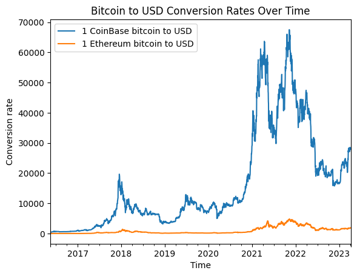

```python
# Write your own code
bitcoin[["date","cb_to_usd","et_to_usd"]].set_index("date").plot()
plt.xlabel("Time")
plt.ylabel("Conversion rate")
plt.legend(["1 CoinBase bitcoin to USD","1 Ethereum bitcoin to USD"])
plt.title("Bitcoin to USD Conversion Rates Over Time")
```

(c) Compute growth rates

- Calculate a new column "growth_cb" which computes the percentage daily

growth rate of "cb_to_usd".

Hint: Use `.diff()` and `.shift(1)` as in Lecture 22

```python
# Write your own code
bitcoin["diff_cb"] = bitcoin["cb_to_usd"].diff()
bitcoin["lag_cb"]    = bitcoin["cb_to_usd"].shift(1)
bitcoin["growth_cb"] = bitcoin["diff_cb"]* 100/bitcoin["lag_cb"]
```

[output not shown]

(d) Flag subset of data and plot

- Create a boolean colum (True/False) "bool_cond" which checks whether

"growth_cb" had a value greater than 15 or less than -15

- Generate a line plot with the "growth_cb" series, label the axes and the title
- Use the command `plt.fill_between()` as in Lecture 22 to create a shaded region

for time periods where "bool_cond" is true.

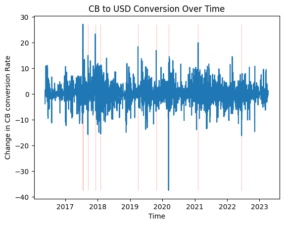

```python
# Write your own code

bitcoin["bool_cond1"] = bitcoin["growth_cb"] > 15
bitcoin["bool_cond2"] = bitcoin["growth_cb"] < -15
bitcoin["bool_cond"] = (bitcoin["bool_cond1"]|bitcoin["bool_cond2"])
plt.plot("date", "growth_cb", data = bitcoin)
plt.xlabel("Time")
plt.ylabel("Change in CB conversion Rate")
plt.title("CB to USD Conversion Over Time")

vec_y = bitcoin["growth_cb"]
plt.fill_between(x= bitcoin["date"],
                 y1 = vec_y.min(),
                 y2 = vec_y.max(),
                 where = bitcoin["bool_cond"],
                 alpha = 0.2,color = "red")

plt.show()
```

(e) Aggregate dataset by time period

- Create an object "month_config" that uses `pd.Grouper()`, setting the key to

the date column and freq to "m" (month)

- Follow the instructions in Lecture 21 to compute an aggregate dataset

by month which computes the standard deviation of "cb_to_usd"

- Display the dataset

```python
# Write your own code
month_config = pd.Grouper(key='date', freq='m')
monthlydata = (bitcoin
               .groupby(month_config)
               .agg(cb_std = ("cb_to_usd","std"))
               .reset_index())
display(monthlydata)
```

|  | date | cb_std |
| --- | --- | --- |
| 0 | 2016-05-31 | 37.522931 |
| 1 | 2016-06-30 | 67.727627 |
| 2 | 2016-07-31 | 13.843294 |
| 3 | 2016-08-31 | 11.616248 |
| 4 | 2016-09-30 | 10.997678 |
| ... | ... | ... |
| 79 | 2022-12-31 | 317.869463 |
| 80 | 2023-01-31 | 2655.277513 |
| 81 | 2023-02-28 | 947.762915 |
| 82 | 2023-03-31 | 2826.126499 |
| 83 | 2023-04-30 | 208.113245 |

84 rows × 2 columns

(f) Convert a dataset to long format

- Convert the currencies dataset to long format using the following inputs

```
var_name   = "type",
value_name = "exchange_rate",
id_vars    = "date",
value_vars = ["cb_to_usd","et_to_usd"]
```

- Display the dataset

Hint: See Lecture 22 for details on `pd.melt()`

```python
# Write your own code
bitcoin_long = pd.melt(bitcoin,
                         var_name   = "type",
                         value_name = "exchange_rate",
                         id_vars='date',
                         value_vars=['cb_to_usd','et_to_usd'])

display(bitcoin_long)
```

|  | date | type | exchange_rate |
| --- | --- | --- | --- |
| 0 | 2016-05-18 | cb_to_usd | 455.56 |
| 1 | 2016-05-19 | cb_to_usd | 438.38 |
| 2 | 2016-05-20 | cb_to_usd | 445.65 |
| 3 | 2016-05-21 | cb_to_usd | 446.28 |
| 4 | 2016-05-22 | cb_to_usd | 442.48 |
| ... | ... | ... | ... |
| 5031 | 2023-04-05 | et_to_usd | 1910.39 |
| 5032 | 2023-04-06 | et_to_usd | 1873.51 |
| 5033 | 2023-04-07 | et_to_usd | 1864.71 |
| 5034 | 2023-04-08 | et_to_usd | 1850.01 |
| 5035 | 2023-04-09 | et_to_usd | 1858.23 |

5036 rows × 3 columns